# Differential Gene Expression Analysis

Colorectal Cancer | Necroptosis, Ferroptosis & Pyroptosis

Kim Williame Lee[^1]

Mark Edward M. Gonzales[^2]

Dr. Anish M.S. Shrestha[^3]

## I. Preliminaries

### Loading libraries

```r
library("tidyverse")
library("tibble")
library("msigdbr")
library("ggplot2")
library("TCGAbiolinks")
library("RNAseqQC")
library("DESeq2")
library("ensembldb")
library("purrr")
library("magrittr")
library("vsn")
library("matrixStats")
library("dplyr")
library("grex")
```

## II. Downloading TCGA gene expression data

Download gene expression data from The Cancer Genome Atlas (TCGA): - `TCGA-COAD` refers to the biospecimen data for colon adenocarcinoma. - `STAR - Counts` pertains to the raw counts.

```r
query_tumor <- GDCquery(
  project = "TCGA-COAD",
  data.category = "Transcriptome Profiling",
  data.type = "Gene Expression Quantification",
  experimental.strategy = "RNA-Seq",
  workflow.type = "STAR - Counts",
  access = "open",
  sample.type = "Primary Tumor"
)
tumor <- getResults(query_tumor)
tumor
```

|  | id | data_format | cases | access | file_name | submitter_id | data_category | type | platform | file_size | created_datetime | md5sum | updated_datetime | file_id | data_type | state | experimental_strategy | version | data_release | project | analysis_id | analysis_state | analysis_submitter_id | analysis_workflow_link | analysis_workflow_type | analysis_workflow_version | sample_type | is_ffpe | cases.submitter_id | … |
| --- | --- | --- | --- | --- | --- | --- | --- | --- | --- | --- | --- | --- | --- | --- | --- | --- | --- | --- | --- | --- | --- | --- | --- | --- | --- | --- | --- | --- | --- | --- |
| 1 | a77adf63-487b-476e-bd33-903005c1dba9 | TSV | TCGA-AA-3854-01A-01R-0905-07 | open | 12b633ae-2a36-40b0-a4a3-c1d5f021fa23.rna_seq.augmented_star_gene_counts.tsv | fc39a087-40da-44d2-a1bb-3eb722b10d38 | Transcriptome Profiling | gene_expression | Illumina | 4210950 | 2022-01-05T19:11:09.703388-06:00 | d4c64e301ed291b5f02720d06bba262a | 2024-07-30T16:13:13.313616-05:00 | a77adf63-487b-476e-bd33-903005c1dba9 | Gene Expression Quantification | released | RNA-Seq | 1 | 32.0 - 42.0 | TCGA-COAD | 54d3995b-0adb-4311-8c73-c435e4bdb91d | released | 12b633ae-2a36-40b0-a4a3-c1d5f021fa23_star__counts | quay.io/ncigdc | STAR - Counts | 470801dfbc085958058a5b50518e4f3a5e4721c3 | Primary Tumor | NA | TCGA-AA-3854 | … |
| 2 | b064b6be-4152-4737-8158-caa0454cf41b | TSV | TCGA-QG-A5YW-01A-11R-A28H-07 | open | f279a2fa-6d1b-476c-b91b-598f5c1bbc34.rna_seq.augmented_star_gene_counts.tsv | 98eead41-b99c-47a2-8964-256683743c53 | Transcriptome Profiling | gene_expression | Illumina | 4239695 | 2022-01-05T19:22:05.341013-06:00 | 87c276b22cb900829a8927062e373717 | 2024-07-30T16:11:48.349606-05:00 | b064b6be-4152-4737-8158-caa0454cf41b | Gene Expression Quantification | released | RNA-Seq | 1 | 32.0 - 42.0 | TCGA-COAD | afaab398-dc08-4f3e-a736-ef11e663cdf8 | released | f279a2fa-6d1b-476c-b91b-598f5c1bbc34_star__counts | https://github.com/NCI-GDC/gdc-rnaseq-cwl/blob/5d8c131bbff59fb0c969217fc1d44e6d1503cd1f/rnaseq-star-align/star2pass.rnaseq_harmonization.cwl | STAR - Counts | 5d8c131bbff59fb0c969217fc1d44e6d1503cd1f | Primary Tumor | NA | TCGA-QG-A5YW | … |
| 3 | 3456d4a1-bb29-4559-8c4e-c9b0e512fae3 | TSV | TCGA-AA-3966-01A-01R-1113-07 | open | 52472301-36c6-4c99-97bd-b016d8a282d6.rna_seq.augmented_star_gene_counts.tsv | 4d8cb5e0-322d-469e-bd90-bb26534ab7bb | Transcriptome Profiling | gene_expression | Illumina | 4216110 | 2022-01-05T19:13:53.623815-06:00 | e0c9d6143465448d43554677eea87adf | 2024-07-30T16:23:13.729340-05:00 | 3456d4a1-bb29-4559-8c4e-c9b0e512fae3 | Gene Expression Quantification | released | RNA-Seq | 1 | 32.0 - 42.0 | TCGA-COAD | 970b4584-9809-4ee7-956f-bf728893c915 | released | 52472301-36c6-4c99-97bd-b016d8a282d6_star__counts | quay.io/ncigdc | STAR - Counts | 470801dfbc085958058a5b50518e4f3a5e4721c3 | Primary Tumor | NA | TCGA-AA-3966 | … |
| 4 | ab6d59e0-21c2-4273-b094-3596d1b8b825 | TSV | TCGA-G4-6626-01A-11R-1774-07 | open | 085e4228-8ed7-44d7-9ab5-8a096434b650.rna_seq.augmented_star_gene_counts.tsv | 228266bc-da5a-4e81-be01-fd71168b8c0a | Transcriptome Profiling | gene_expression | Illumina | 4231843 | 2022-01-05T19:07:13.991395-06:00 | 95984d500a2ac18444f07eed59d18b70 | 2024-07-30T16:20:05.287063-05:00 | ab6d59e0-21c2-4273-b094-3596d1b8b825 | Gene Expression Quantification | released | RNA-Seq | 1 | 32.0 - 42.0 | TCGA-COAD | 6114a871-c923-4318-bce5-4ba0b45ee592 | released | 085e4228-8ed7-44d7-9ab5-8a096434b650_star__counts | https://github.com/NCI-GDC/gdc-rnaseq-cwl/blob/5d8c131bbff59fb0c969217fc1d44e6d1503cd1f/rnaseq-star-align/star2pass.rnaseq_harmonization.cwl | STAR - Counts | 5d8c131bbff59fb0c969217fc1d44e6d1503cd1f | Primary Tumor | NA | TCGA-G4-6626 | … |
| 5 | 00cdff29-697a-4a17-ba67-cf55c006b827 | TSV | TCGA-CM-5868-01A-01R-1653-07 | open | 0f35c851-1cb8-4f75-a661-eae9111b7362.rna_seq.augmented_star_gene_counts.tsv | aa0a8147-5266-40fa-a6ae-ffe289308d8a | Transcriptome Profiling | gene_expression | Illumina | 4241366 | 2022-01-05T19:23:04.371897-06:00 | aac5e0b7ed85c89f985d46bc3386bd22 | 2024-07-30T16:24:17.832336-05:00 | 00cdff29-697a-4a17-ba67-cf55c006b827 | Gene Expression Quantification | released | RNA-Seq | 1 | 32.0 - 42.0 | TCGA-COAD | a35f031e-972c-416b-9820-08b22a6e2682 | released | 0f35c851-1cb8-4f75-a661-eae9111b7362_star__counts | https://github.com/NCI-GDC/gdc-rnaseq-cwl/blob/5d8c131bbff59fb0c969217fc1d44e6d1503cd1f/rnaseq-star-align/star2pass.rnaseq_harmonization.cwl | STAR - Counts | 5d8c131bbff59fb0c969217fc1d44e6d1503cd1f | Primary Tumor | NA | TCGA-CM-5868 | … |
| 6 | 3db2ccda-ad2e-4c6d-932d-0df14befb266 | TSV | TCGA-AA-3973-01A-01R-1022-07 | open | e1d0ac40-05b3-4ab8-b64b-f42613e97cc7.rna_seq.augmented_star_gene_counts.tsv | 2b637e1c-e984-45a4-adc5-7b07b435433d | Transcriptome Profiling | gene_expression | Illumina | 4210406 | 2022-01-05T19:09:26.484236-06:00 | 05b20ca2a6f9698eb13e1bdd2afa60f2 | 2024-07-30T16:21:40.972500-05:00 | 3db2ccda-ad2e-4c6d-932d-0df14befb266 | Gene Expression Quantification | released | RNA-Seq | 1 | 32.0 - 42.0 | TCGA-COAD | 42fb4880-f75a-4510-91cf-c955300952e5 | released | e1d0ac40-05b3-4ab8-b64b-f42613e97cc7_star__counts | quay.io/ncigdc | STAR - Counts | 470801dfbc085958058a5b50518e4f3a5e4721c3 | Primary Tumor | NA | TCGA-AA-3973 | … |
| 7 | 7079a45a-d00b-44f3-9b0d-8c686180966b | TSV | TCGA-AA-3673-01A-01R-0905-07 | open | 1ba54adc-765f-403a-8987-61f94db2a65b.rna_seq.augmented_star_gene_counts.tsv | 293f72a1-a1e9-42b4-960f-13dbc47a3587 | Transcriptome Profiling | gene_expression | Illumina | 4221087 | 2022-01-05T19:19:14.197741-06:00 | c22797ca81cf34161df6568ef15cf833 | 2024-07-30T16:07:40.089707-05:00 | 7079a45a-d00b-44f3-9b0d-8c686180966b | Gene Expression Quantification | released | RNA-Seq | 1 | 32.0 - 42.0 | TCGA-COAD | f955f60b-44df-4087-93c1-48dfd3382997 | released | 1ba54adc-765f-403a-8987-61f94db2a65b_star__counts | quay.io/ncigdc | STAR - Counts | 470801dfbc085958058a5b50518e4f3a5e4721c3 | Primary Tumor | NA | TCGA-AA-3673 | … |
| 8 | 3530cc00-2ddb-42ad-98b7-997310495567 | TSV | TCGA-CM-6675-01A-11R-1839-07 | open | bf5f606f-17ae-46bb-b687-7863ab3d97b1.rna_seq.augmented_star_gene_counts.tsv | 4d7ee9f4-875e-43ee-bbf0-19a38346e813 | Transcriptome Profiling | gene_expression | Illumina | 4236111 | 2022-01-05T19:35:54.579600-06:00 | 9003969732d9c1841a898b9fbb09507f | 2024-07-30T16:07:59.778505-05:00 | 3530cc00-2ddb-42ad-98b7-997310495567 | Gene Expression Quantification | released | RNA-Seq | 1 | 32.0 - 42.0 | TCGA-COAD | f37a7044-3286-46a0-81c2-566911fd2860 | released | bf5f606f-17ae-46bb-b687-7863ab3d97b1_star__counts | https://github.com/NCI-GDC/gdc-rnaseq-cwl/blob/5d8c131bbff59fb0c969217fc1d44e6d1503cd1f/rnaseq-star-align/star2pass.rnaseq_harmonization.cwl | STAR - Counts | 5d8c131bbff59fb0c969217fc1d44e6d1503cd1f | Primary Tumor | NA | TCGA-CM-6675 | … |
| 9 | 57c425f6-9625-407e-93b8-1d03858fd1f6 | TSV | TCGA-AA-3538-01A-01R-0821-07 | open | 576325e7-0f30-406c-9147-80e3edcf8b57.rna_seq.augmented_star_gene_counts.tsv | 6d53670b-9aea-4996-a2a8-c769e1c913b1 | Transcriptome Profiling | gene_expression | Illumina | 4215375 | 2022-01-05T19:12:34.448262-06:00 | e236223206ffb9832900d42d7f4d03c3 | 2024-07-30T16:09:54.171551-05:00 | 57c425f6-9625-407e-93b8-1d03858fd1f6 | Gene Expression Quantification | released | RNA-Seq | 1 | 32.0 - 42.0 | TCGA-COAD | feb707c2-0b29-47af-aa99-6fad707dcbb9 | released | 576325e7-0f30-406c-9147-80e3edcf8b57_star__counts | quay.io/ncigdc | STAR - Counts | 470801dfbc085958058a5b50518e4f3a5e4721c3 | Primary Tumor | NA | TCGA-AA-3538 | … |
| 10 | b18dafa7-46e3-45da-ba05-c9941305056e | TSV | TCGA-AZ-4614-01A-01R-1410-07 | open | 2cf34da3-fe4b-42b4-bd32-9bf8930b6054.rna_seq.augmented_star_gene_counts.tsv | 1b908a27-7d4d-4652-bcac-aeb79c42377d | Transcriptome Profiling | gene_expression | Illumina | 4209657 | 2022-01-05T19:10:07.285460-06:00 | 034a308769377239beca6468d4d4d7ff | 2024-07-30T16:24:11.571047-05:00 | b18dafa7-46e3-45da-ba05-c9941305056e | Gene Expression Quantification | released | RNA-Seq | 1 | 32.0 - 42.0 | TCGA-COAD | 38e32044-9d12-40a7-812a-61dc5cf7398c | released | 2cf34da3-fe4b-42b4-bd32-9bf8930b6054_star__counts | quay.io/ncigdc | STAR - Counts | 470801dfbc085958058a5b50518e4f3a5e4721c3 | Primary Tumor | NA | TCGA-AZ-4614 | … |

[output cut: 471 more lines]

```r
query_normal <- GDCquery(
  project = "TCGA-COAD",
  data.category = "Transcriptome Profiling",
  data.type = "Gene Expression Quantification",
  experimental.strategy = "RNA-Seq",
  workflow.type = "STAR - Counts",
  access = "open",
  sample.type = "Solid Tissue Normal"
)
normal <- getResults(query_normal)
normal
```

|  | id | data_format | cases | access | file_name | submitter_id | data_category | type | platform | file_size | created_datetime | md5sum | updated_datetime | file_id | data_type | state | experimental_strategy | version | data_release | project | analysis_id | analysis_state | analysis_submitter_id | analysis_workflow_link | analysis_workflow_type | analysis_workflow_version | sample_type | is_ffpe | cases.submitter_id | … |
| --- | --- | --- | --- | --- | --- | --- | --- | --- | --- | --- | --- | --- | --- | --- | --- | --- | --- | --- | --- | --- | --- | --- | --- | --- | --- | --- | --- | --- | --- | --- |
| 1 | 530bff57-a892-435d-94df-ddc7dbd45fb9 | TSV | TCGA-A6-2686-11A-01R-A32Z-07 | open | ba6ae99d-73a8-48a5-b038-749434ae2f11.rna_seq.augmented_star_gene_counts.tsv | 0345695a-714c-42a6-bf81-cce2587af049 | Transcriptome Profiling | gene_expression | Illumina | 4237522 | 2022-01-05T19:43:12.411547-06:00 | d6bb414eb7f4f3645e3608cbb29c60c0 | 2024-07-30T16:23:47.022098-05:00 | 530bff57-a892-435d-94df-ddc7dbd45fb9 | Gene Expression Quantification | released | RNA-Seq | 1 | 32.0 - 42.0 | TCGA-COAD | 281e1e7f-c1e2-4c41-a836-ec1974d48261 | released | ba6ae99d-73a8-48a5-b038-749434ae2f11_star__counts | https://github.com/NCI-GDC/gdc-rnaseq-cwl/blob/5d8c131bbff59fb0c969217fc1d44e6d1503cd1f/rnaseq-star-align/star2pass.rnaseq_harmonization.cwl | STAR - Counts | 5d8c131bbff59fb0c969217fc1d44e6d1503cd1f | Solid Tissue Normal | NA | TCGA-A6-2686 | … |
| 2 | 756b1010-09e1-425f-8682-f9f8144b3c4c | TSV | TCGA-AA-3514-11A-01R-A32Z-07 | open | b3e4282d-55bf-43ab-a9af-9e4ec31240ed.rna_seq.augmented_star_gene_counts.tsv | fe34e798-a031-4352-bf1c-03ba5ca0f3c5 | Transcriptome Profiling | gene_expression | Illumina | 4229447 | 2022-01-05T19:39:07.207885-06:00 | 8c9dffa7bc74936ab13c1a5277c54483 | 2024-07-30T16:24:15.442783-05:00 | 756b1010-09e1-425f-8682-f9f8144b3c4c | Gene Expression Quantification | released | RNA-Seq | 1 | 32.0 - 42.0 | TCGA-COAD | 62e126fa-f86f-49fa-a777-b8bac12c3543 | released | b3e4282d-55bf-43ab-a9af-9e4ec31240ed_star__counts | https://github.com/NCI-GDC/gdc-rnaseq-cwl/blob/5d8c131bbff59fb0c969217fc1d44e6d1503cd1f/rnaseq-star-align/star2pass.rnaseq_harmonization.cwl | STAR - Counts | 5d8c131bbff59fb0c969217fc1d44e6d1503cd1f | Solid Tissue Normal | NA | TCGA-AA-3514 | … |
| 3 | 026818a6-8180-4d9c-9357-b88a832b374e | TSV | TCGA-A6-5659-11A-01R-1653-07 | open | d4d783e3-e8df-4cbd-9f8a-53120abf58a1.rna_seq.augmented_star_gene_counts.tsv | 81820cdf-3558-4d71-9d75-134c97e456d1 | Transcriptome Profiling | gene_expression | Illumina | 4211909 | 2022-01-05T19:15:13.360608-06:00 | 99d83193b0bc66f217ae1d1686611665 | 2024-07-30T16:13:51.146521-05:00 | 026818a6-8180-4d9c-9357-b88a832b374e | Gene Expression Quantification | released | RNA-Seq | 1 | 32.0 - 42.0 | TCGA-COAD | 5d688f14-22bf-45f9-ad13-3915281015aa | released | d4d783e3-e8df-4cbd-9f8a-53120abf58a1_star__counts | https://github.com/NCI-GDC/gdc-rnaseq-cwl/blob/5d8c131bbff59fb0c969217fc1d44e6d1503cd1f/rnaseq-star-align/star2pass.rnaseq_harmonization.cwl | STAR - Counts | 5d8c131bbff59fb0c969217fc1d44e6d1503cd1f | Solid Tissue Normal | NA | TCGA-A6-5659 | … |
| 4 | bb6cdb4c-198d-4908-a2cc-c1e760083aa8 | TSV | TCGA-F4-6704-11A-01R-1839-07 | open | 6c7a6119-e82e-4fc1-b3ce-cc3c62ce7f7e.rna_seq.augmented_star_gene_counts.tsv | 817331f3-53fb-4a49-8d3a-dfa508966c31 | Transcriptome Profiling | gene_expression | Illumina | 4241863 | 2022-01-05T19:37:09.887941-06:00 | 3041a9cfb1c9e20c043e0e40a1a055f1 | 2024-07-30T16:25:38.667211-05:00 | bb6cdb4c-198d-4908-a2cc-c1e760083aa8 | Gene Expression Quantification | released | RNA-Seq | 1 | 32.0 - 42.0 | TCGA-COAD | 71850efd-bd24-432a-8186-ebbb9dd98f4f | released | 6c7a6119-e82e-4fc1-b3ce-cc3c62ce7f7e_star__counts | https://github.com/NCI-GDC/gdc-rnaseq-cwl/blob/5d8c131bbff59fb0c969217fc1d44e6d1503cd1f/rnaseq-star-align/star2pass.rnaseq_harmonization.cwl | STAR - Counts | 5d8c131bbff59fb0c969217fc1d44e6d1503cd1f | Solid Tissue Normal | NA | TCGA-F4-6704 | … |
| 5 | b03ee962-4866-4e02-bba9-357e1542b3ca | TSV | TCGA-AZ-6600-11A-01R-1774-07 | open | fb58609f-7727-402d-ba81-e42a99acff6c.rna_seq.augmented_star_gene_counts.tsv | dcb47e8b-00d5-4fea-8ae1-5d5db09c2e5d | Transcriptome Profiling | gene_expression | Illumina | 4228365 | 2022-01-05T19:23:28.975692-06:00 | 35e6a5115b6152e69519d967c5dd89ee | 2024-07-30T16:11:54.414243-05:00 | b03ee962-4866-4e02-bba9-357e1542b3ca | Gene Expression Quantification | released | RNA-Seq | 1 | 32.0 - 42.0 | TCGA-COAD | 73414f34-7fc0-4ba4-9076-2ccced0071a6 | released | fb58609f-7727-402d-ba81-e42a99acff6c_star__counts | https://github.com/NCI-GDC/gdc-rnaseq-cwl/blob/5d8c131bbff59fb0c969217fc1d44e6d1503cd1f/rnaseq-star-align/star2pass.rnaseq_harmonization.cwl | STAR - Counts | 5d8c131bbff59fb0c969217fc1d44e6d1503cd1f | Solid Tissue Normal | NA | TCGA-AZ-6600 | … |
| 6 | 5f4a46f3-0fbe-4521-ab43-20bcb15793f1 | TSV | TCGA-AA-3663-11A-01R-1723-07 | open | 42b88263-95a0-43fb-b7e4-a840df8d4a92.rna_seq.augmented_star_gene_counts.tsv | a00d6b52-1081-44be-97da-96c941ae585a | Transcriptome Profiling | gene_expression | Illumina | 4228816 | 2022-01-05T19:40:14.696970-06:00 | 5ecf011385caa717c52feb8ff16a5c5e | 2024-07-30T16:23:00.793659-05:00 | 5f4a46f3-0fbe-4521-ab43-20bcb15793f1 | Gene Expression Quantification | released | RNA-Seq | 1 | 32.0 - 42.0 | TCGA-COAD | 25bffec9-3bce-4a1a-b92a-6475d0ca1b99 | released | 42b88263-95a0-43fb-b7e4-a840df8d4a92_star__counts | https://github.com/NCI-GDC/gdc-rnaseq-cwl/blob/5d8c131bbff59fb0c969217fc1d44e6d1503cd1f/rnaseq-star-align/star2pass.rnaseq_harmonization.cwl | STAR - Counts | 5d8c131bbff59fb0c969217fc1d44e6d1503cd1f | Solid Tissue Normal | NA | TCGA-AA-3663 | … |
| 7 | ee9a460d-1b5e-451e-8b4b-7608a21f093d | TSV | TCGA-A6-2684-11A-01R-A32Z-07 | open | c1b43ace-3691-4c64-9fb1-4c1e94735b1e.rna_seq.augmented_star_gene_counts.tsv | c5b2ec6e-6f38-4507-9cb4-e8b91ade9fa3 | Transcriptome Profiling | gene_expression | Illumina | 4229253 | 2022-01-05T19:22:09.150788-06:00 | 484c67fb0444a8cff0b6b6ff1fcf36b2 | 2024-07-30T16:17:24.870845-05:00 | ee9a460d-1b5e-451e-8b4b-7608a21f093d | Gene Expression Quantification | released | RNA-Seq | 1 | 32.0 - 42.0 | TCGA-COAD | 3bf5f5ff-317f-406e-9b82-a9eb3a2a685c | released | c1b43ace-3691-4c64-9fb1-4c1e94735b1e_star__counts | https://github.com/NCI-GDC/gdc-rnaseq-cwl/blob/5d8c131bbff59fb0c969217fc1d44e6d1503cd1f/rnaseq-star-align/star2pass.rnaseq_harmonization.cwl | STAR - Counts | 5d8c131bbff59fb0c969217fc1d44e6d1503cd1f | Solid Tissue Normal | NA | TCGA-A6-2684 | … |
| 8 | cc6e41a2-f851-4a1a-a7b7-91db1076d6ee | TSV | TCGA-A6-2675-11A-01R-1723-07 | open | 796775e9-e68a-4fb5-bdc5-d9ce33a981d9.rna_seq.augmented_star_gene_counts.tsv | 22ddece9-d57f-43ca-b6d1-fdd5cf9c6272 | Transcriptome Profiling | gene_expression | Illumina | 4228545 | 2022-01-05T19:34:59.273133-06:00 | 5ed4840bfb1595f58f3e2d4d8e62c382 | 2024-07-30T16:13:52.320225-05:00 | cc6e41a2-f851-4a1a-a7b7-91db1076d6ee | Gene Expression Quantification | released | RNA-Seq | 1 | 32.0 - 42.0 | TCGA-COAD | 854be2f8-7c3e-4e7f-bf4c-971294affc0a | released | 796775e9-e68a-4fb5-bdc5-d9ce33a981d9_star__counts | https://github.com/NCI-GDC/gdc-rnaseq-cwl/blob/5d8c131bbff59fb0c969217fc1d44e6d1503cd1f/rnaseq-star-align/star2pass.rnaseq_harmonization.cwl | STAR - Counts | 5d8c131bbff59fb0c969217fc1d44e6d1503cd1f | Solid Tissue Normal | NA | TCGA-A6-2675 | … |
| 9 | 8de9cb61-cdb8-47f3-8c83-8ebaac2d0cb4 | TSV | TCGA-A6-2679-11A-01R-A32Z-07 | open | f14f75eb-ca4e-4503-9da9-75981dbd3a2e.rna_seq.augmented_star_gene_counts.tsv | 1a576d58-3616-453c-94a6-44e1154da4dc | Transcriptome Profiling | gene_expression | Illumina | 4232531 | 2022-01-05T19:24:30.383764-06:00 | 0563a7a2e39caae3edcb71081680fadf | 2024-07-30T16:12:11.439534-05:00 | 8de9cb61-cdb8-47f3-8c83-8ebaac2d0cb4 | Gene Expression Quantification | released | RNA-Seq | 1 | 32.0 - 42.0 | TCGA-COAD | 5f1a6c81-9c2e-4542-8ed6-c842118cf618 | released | f14f75eb-ca4e-4503-9da9-75981dbd3a2e_star__counts | https://github.com/NCI-GDC/gdc-rnaseq-cwl/blob/5d8c131bbff59fb0c969217fc1d44e6d1503cd1f/rnaseq-star-align/star2pass.rnaseq_harmonization.cwl | STAR - Counts | 5d8c131bbff59fb0c969217fc1d44e6d1503cd1f | Solid Tissue Normal | NA | TCGA-A6-2679 | … |
| 10 | fc084c37-52f5-4b88-b962-8d27bf42d99c | TSV | TCGA-A6-5667-11A-01R-1723-07 | open | d7319fc1-a636-4786-a026-14e248976391.rna_seq.augmented_star_gene_counts.tsv | 4a038174-bb96-4e80-8f13-9c62c3f334c7 | Transcriptome Profiling | gene_expression | Illumina | 4234241 | 2022-01-05T19:28:07.402356-06:00 | 003fefb76ee39db4a982b18c266253a5 | 2024-07-30T16:07:41.224785-05:00 | fc084c37-52f5-4b88-b962-8d27bf42d99c | Gene Expression Quantification | released | RNA-Seq | 1 | 32.0 - 42.0 | TCGA-COAD | 05c8ccec-9e7f-4165-b828-5633bebcd635 | released | d7319fc1-a636-4786-a026-14e248976391_star__counts | https://github.com/NCI-GDC/gdc-rnaseq-cwl/blob/5d8c131bbff59fb0c969217fc1d44e6d1503cd1f/rnaseq-star-align/star2pass.rnaseq_harmonization.cwl | STAR - Counts | 5d8c131bbff59fb0c969217fc1d44e6d1503cd1f | Solid Tissue Normal | NA | TCGA-A6-5667 | … |

[output cut: 31 more lines]

Consider only samples with both normal and malignant tissues.

```r
submitter_ids <- inner_join(tumor, normal, by = "cases.submitter_id") %>%
  dplyr::select(cases.submitter_id)
tumor <- tumor %>%
  dplyr::filter(cases.submitter_id %in% submitter_ids$cases.submitter_id)
normal <- normal %>%
  dplyr::filter(cases.submitter_id %in% submitter_ids$cases.submitter_id)

samples <- rbind(tumor, normal)
invisible(unique(samples$sample_type))
samples
```

| id | data_format | cases | access | file_name | submitter_id | data_category | type | platform | file_size | created_datetime | md5sum | updated_datetime | file_id | data_type | state | experimental_strategy | version | data_release | project | analysis_id | analysis_state | analysis_submitter_id | analysis_workflow_link | analysis_workflow_type | analysis_workflow_version | sample_type | is_ffpe | cases.submitter_id | sample.submitter_id |
| --- | --- | --- | --- | --- | --- | --- | --- | --- | --- | --- | --- | --- | --- | --- | --- | --- | --- | --- | --- | --- | --- | --- | --- | --- | --- | --- | --- | --- | --- |
| 75b92663-674e-45ea-9ff8-cf3ce33f8839 | TSV | TCGA-A6-2686-01A-01R-A32Z-07 | open | 9f5f50f9-3524-4767-94d3-d89dca19f7ca.rna_seq.augmented_star_gene_counts.tsv | 20e2040c-858e-4dfa-8777-ed5039f4f527 | Transcriptome Profiling | gene_expression | Illumina | 4237920 | 2022-01-05T19:34:51.396820-06:00 | 2262f19a1d6e0ad2656c23556ed64b4e | 2024-07-30T16:13:39.896650-05:00 | 75b92663-674e-45ea-9ff8-cf3ce33f8839 | Gene Expression Quantification | released | RNA-Seq | 1 | 32.0 - 42.0 | TCGA-COAD | 41bc602b-6baa-4c0c-bebe-62d3236c8bd2 | released | 9f5f50f9-3524-4767-94d3-d89dca19f7ca_star__counts | https://github.com/NCI-GDC/gdc-rnaseq-cwl/blob/5d8c131bbff59fb0c969217fc1d44e6d1503cd1f/rnaseq-star-align/star2pass.rnaseq_harmonization.cwl | STAR - Counts | 5d8c131bbff59fb0c969217fc1d44e6d1503cd1f | Primary Tumor | NA | TCGA-A6-2686 | TCGA-A6-2686-01A |
| b3ebddcc-1177-40a7-baa5-51000c1b7123 | TSV | TCGA-AA-3514-01A-02R-0821-07 | open | 290b89f5-2a44-424b-b77d-a190dcb93e07.rna_seq.augmented_star_gene_counts.tsv | ce6950db-b998-4154-aa35-d81d8a66eb83 | Transcriptome Profiling | gene_expression | Illumina | 4199935 | 2022-01-05T19:34:55.288639-06:00 | 89a98004db97853466af5c0f9f869ef9 | 2024-07-30T16:16:20.355156-05:00 | b3ebddcc-1177-40a7-baa5-51000c1b7123 | Gene Expression Quantification | released | RNA-Seq | 1 | 32.0 - 42.0 | TCGA-COAD | c7efd3bb-b678-4271-9741-24fd267117f4 | released | 290b89f5-2a44-424b-b77d-a190dcb93e07_star__counts | quay.io/ncigdc | STAR - Counts | 470801dfbc085958058a5b50518e4f3a5e4721c3 | Primary Tumor | NA | TCGA-AA-3514 | TCGA-AA-3514-01A |
| ed0ffe0c-0094-41b3-86aa-20492e0d0157 | TSV | TCGA-A6-5659-01B-04R-A277-07 | open | 69550f7f-5251-4657-863b-bd35d69c82c4.rna_seq.augmented_star_gene_counts.tsv | 6e7b3c72-9cbb-400b-b524-51e68b597486 | Transcriptome Profiling | gene_expression | Illumina | 4215532 | 2022-01-05T19:38:43.015271-06:00 | 16cd926c06e0b9ca02eed536b54f96a8 | 2024-07-30T16:08:19.893740-05:00 | ed0ffe0c-0094-41b3-86aa-20492e0d0157 | Gene Expression Quantification | released | RNA-Seq | 1 | 32.0 - 42.0 | TCGA-COAD | 790ca12e-5c39-49ed-b20a-a6c0f88ea0f9 | released | 69550f7f-5251-4657-863b-bd35d69c82c4_star__counts | https://github.com/NCI-GDC/gdc-rnaseq-cwl/blob/5d8c131bbff59fb0c969217fc1d44e6d1503cd1f/rnaseq-star-align/star2pass.rnaseq_harmonization.cwl | STAR - Counts | 5d8c131bbff59fb0c969217fc1d44e6d1503cd1f | Primary Tumor | NA | TCGA-A6-5659 | TCGA-A6-5659-01B |
| f01575cb-c8fa-4a21-9e61-768d25cabc58 | TSV | TCGA-A6-5659-01A-01R-A278-07 | open | b503bcc9-714d-40aa-8709-3b4577ce8007.rna_seq.augmented_star_gene_counts.tsv | 57e7fc13-0563-41ea-84a2-2ce8361d10eb | Transcriptome Profiling | gene_expression | Illumina | 4222697 | 2022-01-05T19:25:21.255887-06:00 | ee7a03ee812dc08c46e70046d6c9aa88 | 2024-07-30T16:07:42.434465-05:00 | f01575cb-c8fa-4a21-9e61-768d25cabc58 | Gene Expression Quantification | released | RNA-Seq | 1 | 32.0 - 42.0 | TCGA-COAD | cc83b065-802d-41d1-bd57-69c0da0ce544 | released | b503bcc9-714d-40aa-8709-3b4577ce8007_star__counts | https://github.com/NCI-GDC/gdc-rnaseq-cwl/blob/5d8c131bbff59fb0c969217fc1d44e6d1503cd1f/rnaseq-star-align/star2pass.rnaseq_harmonization.cwl | STAR - Counts | 5d8c131bbff59fb0c969217fc1d44e6d1503cd1f | Primary Tumor | NA | TCGA-A6-5659 | TCGA-A6-5659-01A |
| cc01ff43-77ea-43a2-9180-d7b40ac6b26e | TSV | TCGA-A6-5659-01A-01R-1653-07 | open | 2b2c2ebc-e83c-442e-88ae-1a2569ac892f.rna_seq.augmented_star_gene_counts.tsv | ec804345-5ad0-4fd9-a9ef-c49347f4bf76 | Transcriptome Profiling | gene_expression | Illumina | 4234878 | 2022-01-05T19:20:31.998871-06:00 | 604b8074fc8add00598b46a6e8eef6cb | 2024-07-30T16:13:57.565762-05:00 | cc01ff43-77ea-43a2-9180-d7b40ac6b26e | Gene Expression Quantification | released | RNA-Seq | 1 | 32.0 - 42.0 | TCGA-COAD | ad88ddf9-7881-44aa-94e5-d0d6f6cd380f | released | 2b2c2ebc-e83c-442e-88ae-1a2569ac892f_star__counts | https://github.com/NCI-GDC/gdc-rnaseq-cwl/blob/5d8c131bbff59fb0c969217fc1d44e6d1503cd1f/rnaseq-star-align/star2pass.rnaseq_harmonization.cwl | STAR - Counts | 5d8c131bbff59fb0c969217fc1d44e6d1503cd1f | Primary Tumor | NA | TCGA-A6-5659 | TCGA-A6-5659-01A |
| 5e7e2b3e-93f5-4a3f-b1d2-f9e0f58ef87f | TSV | TCGA-F4-6704-01A-11R-1839-07 | open | 8aaaa253-87d2-4292-aeb2-1b207b71abef.rna_seq.augmented_star_gene_counts.tsv | a80e781f-9146-4071-8fe8-4c56db5a21fb | Transcriptome Profiling | gene_expression | Illumina | 4254660 | 2022-01-05T19:39:44.183979-06:00 | e0d977ab3c0abd19dd4f5b7960ffb832 | 2024-07-30T16:26:31.778991-05:00 | 5e7e2b3e-93f5-4a3f-b1d2-f9e0f58ef87f | Gene Expression Quantification | released | RNA-Seq | 1 | 32.0 - 42.0 | TCGA-COAD | c238f687-c823-44fe-80c6-e2ab3b3d84be | released | 8aaaa253-87d2-4292-aeb2-1b207b71abef_star__counts | https://github.com/NCI-GDC/gdc-rnaseq-cwl/blob/5d8c131bbff59fb0c969217fc1d44e6d1503cd1f/rnaseq-star-align/star2pass.rnaseq_harmonization.cwl | STAR - Counts | 5d8c131bbff59fb0c969217fc1d44e6d1503cd1f | Primary Tumor | NA | TCGA-F4-6704 | TCGA-F4-6704-01A |
| 13a72fbf-f601-4f67-aca4-796716f78293 | TSV | TCGA-AZ-6600-01A-11R-1774-07 | open | 9ef8ac96-eaba-447f-ac45-aa44f2182c50.rna_seq.augmented_star_gene_counts.tsv | 82dfdc30-7a17-4fc6-956f-65ff9def1e91 | Transcriptome Profiling | gene_expression | Illumina | 4239225 | 2022-01-05T19:33:04.584004-06:00 | 7eb0a8da95109011efe0bd8f14773554 | 2024-07-30T02:14:09.504226-05:00 | 13a72fbf-f601-4f67-aca4-796716f78293 | Gene Expression Quantification | released | RNA-Seq | 1 | 32.0 - 42.0 | TCGA-COAD | 7b929a3d-7908-4684-8df6-20b95f993fae | released | 9ef8ac96-eaba-447f-ac45-aa44f2182c50_star__counts | https://github.com/NCI-GDC/gdc-rnaseq-cwl/blob/5d8c131bbff59fb0c969217fc1d44e6d1503cd1f/rnaseq-star-align/star2pass.rnaseq_harmonization.cwl | STAR - Counts | 5d8c131bbff59fb0c969217fc1d44e6d1503cd1f | Primary Tumor | NA | TCGA-AZ-6600 | TCGA-AZ-6600-01A |
| ec9db2fa-3020-45a0-8400-1fa607fdbf05 | TSV | TCGA-AA-3663-01A-01R-1723-07 | open | bf312cd5-e251-4d63-95b5-c379b3ef5ded.rna_seq.augmented_star_gene_counts.tsv | 7034703f-15f9-46c1-a92a-d7d1773d918e | Transcriptome Profiling | gene_expression | Illumina | 4220728 | 2022-01-05T19:23:44.312909-06:00 | 06594cc1ba71b8a43cfffe0585c89f3f | 2024-07-30T16:20:58.054250-05:00 | ec9db2fa-3020-45a0-8400-1fa607fdbf05 | Gene Expression Quantification | released | RNA-Seq | 1 | 32.0 - 42.0 | TCGA-COAD | 7626a056-ad44-43a1-876d-21ed1b6b8e74 | released | bf312cd5-e251-4d63-95b5-c379b3ef5ded_star__counts | https://github.com/NCI-GDC/gdc-rnaseq-cwl/blob/5d8c131bbff59fb0c969217fc1d44e6d1503cd1f/rnaseq-star-align/star2pass.rnaseq_harmonization.cwl | STAR - Counts | 5d8c131bbff59fb0c969217fc1d44e6d1503cd1f | Primary Tumor | NA | TCGA-AA-3663 | TCGA-AA-3663-01A |
| bfb91635-bf2c-4311-8b57-33c15b520869 | TSV | TCGA-A6-2684-01A-01R-A278-07 | open | 19645f04-0021-4b2d-ad56-b1342c6ca519.rna_seq.augmented_star_gene_counts.tsv | afe8870d-1d52-40fa-bfba-f9a757e72de2 | Transcriptome Profiling | gene_expression | Illumina | 4214404 | 2022-01-05T19:28:23.492226-06:00 | d01810a3645aa882116d4bfc77a3c635 | 2024-07-30T16:23:53.263205-05:00 | bfb91635-bf2c-4311-8b57-33c15b520869 | Gene Expression Quantification | released | RNA-Seq | 1 | 32.0 - 42.0 | TCGA-COAD | 93c13ad0-0675-4f6f-b620-37f419b3c91c | released | 19645f04-0021-4b2d-ad56-b1342c6ca519_star__counts | https://github.com/NCI-GDC/gdc-rnaseq-cwl/blob/5d8c131bbff59fb0c969217fc1d44e6d1503cd1f/rnaseq-star-align/star2pass.rnaseq_harmonization.cwl | STAR - Counts | 5d8c131bbff59fb0c969217fc1d44e6d1503cd1f | Primary Tumor | NA | TCGA-A6-2684 | TCGA-A6-2684-01A |
| b7aa491d-f50f-4f9b-b8ac-1572cd6cd1ef | TSV | TCGA-A6-2684-01C-08R-A277-07 | open | ba2b0b86-f7f1-47f7-b0fd-bec3f623febb.rna_seq.augmented_star_gene_counts.tsv | 8daa876f-6154-454a-81ce-09ef97d398f2 | Transcriptome Profiling | gene_expression | Illumina | 4224222 | 2022-01-05T19:21:22.344625-06:00 | eff3fbb4e81121e0a15bb27c0c3765e2 | 2024-07-30T16:16:58.446737-05:00 | b7aa491d-f50f-4f9b-b8ac-1572cd6cd1ef | Gene Expression Quantification | released | RNA-Seq | 1 | 32.0 - 42.0 | TCGA-COAD | 3eb49f94-2d50-45fd-bd3b-5bbfcba96ef4 | released | ba2b0b86-f7f1-47f7-b0fd-bec3f623febb_star__counts | https://github.com/NCI-GDC/gdc-rnaseq-cwl/blob/5d8c131bbff59fb0c969217fc1d44e6d1503cd1f/rnaseq-star-align/star2pass.rnaseq_harmonization.cwl | STAR - Counts | 5d8c131bbff59fb0c969217fc1d44e6d1503cd1f | Primary Tumor | NA | TCGA-A6-2684 | TCGA-A6-2684-01C |

[output cut: 77 more lines]

Download only samples with both normal and malignant tissues.

To impose this filtering, we set the `barcode` argument of `GDCquery` to `samples$sample.submitter_id` (which was generated in the previous cell).

```r
query_coad <- GDCquery(
  project = "TCGA-COAD",
  data.category = "Transcriptome Profiling",
  data.type = "Gene Expression Quantification",
  experimental.strategy = "RNA-Seq",
  workflow.type = "STAR - Counts",
  access = "open",
  sample.type = c("Solid Tissue Normal", "Primary Tumor"),
  barcode = as.list(samples$sample.submitter_id)
)
```

If this is your first time running this notebook (i.e., you have not yet downloaded the results of the query in the previous block), uncomment the code block below.

```r
GDC_DIR = "../data/public/GDCdata"

# GDCdownload(
#   query_coad,
#   directory = GDC_DIR
# )
```

Running the code block above should generate and populate a directory named `GDCdata`.

## III. Data preprocessing

Construct the RNA-seq count matrix.

```r
tcga_coad_data <- GDCprepare(
  query_coad,
  directory = GDC_DIR,
  summarizedExperiment = TRUE
)
```

```r
count_matrix <- assay(tcga_coad_data, "unstranded")

# Remove duplicate entries
count_matrix_df <- data.frame(count_matrix)
count_matrix_df <- count_matrix_df[!duplicated(count_matrix_df), ]
count_matrix <- data.matrix(count_matrix_df)
rownames(count_matrix) <- cleanid(rownames(count_matrix))
count_matrix <- count_matrix[!(duplicated(rownames(count_matrix)) | duplicated(rownames(count_matrix), fromLast = TRUE)), ]

head(count_matrix[1:5, 1:4])
```

```
                TCGA.A6.2686.01A.01R.A32Z.07 TCGA.AA.3514.01A.02R.0821.07 TCGA.A6.5659.01B.04R.A277.07 TCGA.A6.5659.01A.01R.A278.07
ENSG00000000003                         7085                         1832                        15822                        30330
ENSG00000000005                           39                            3                           61                          114
ENSG00000000419                         2094                          239                         1945                         6836
ENSG00000000457                          769                          130                          543                         1198
ENSG00000000460                          395                          155                          609                         1131
```

Format the `samples` table so that it can be fed as input to DESeq2.

```r
rownames(samples) <- samples$cases
samples <- samples %>%
  dplyr::select(case = "cases.submitter_id", type = "sample_type")
samples$type <- str_replace(samples$type, "Solid Tissue Normal", "normal")
samples$type <- str_replace(samples$type, "Primary Tumor", "tumor")
```

DESeq2 requires the row names of `samples` should be identical to the column names of `count_matrix`.

```r
colnames(count_matrix) <- gsub(x = colnames(count_matrix), pattern = "\\.", replacement = "-")
count_matrix <- count_matrix[, rownames(samples)]

# Sanity check
all(colnames(count_matrix) == rownames(samples))
```

## IV. Differential gene expression analysis

References:

- Official documentation: https://www.bioconductor.org/packages/release/bioc/vignettes/DESeq2/inst/doc/DESeq2.html
- Good balance of theory and hands-on: https://hbctraining.github.io/DGE_workshop/lessons/04_DGE_DESeq2_analysis.html
- Quality control: https://cran.r-project.org/web/packages/RNAseqQC/vignettes/introduction.html

Construct the `DESeqDataSet` object.

```r
dds <- DESeqDataSetFromMatrix(
  countData = count_matrix,
  colData = samples,
  design = ~type
)
```

### Quality Control

Display quality control (QC) plots (refer to https://cran.r-project.org/web/packages/RNAseqQC/vignettes/introduction.html)

- Total sample counts
  - Total number of counts for each sample
  - We typically expect all samples to have total counts within the same order of magnitude
- Library complexity
  - What fraction of counts is taken up by what fraction of genes
  - Samples showing a different library complexity than the rest might be considered low quality
- Gene detection
  - Number of detected genes for each sample

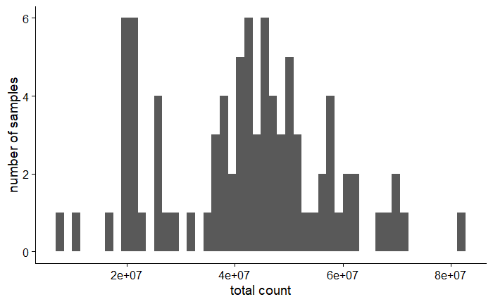

```r
plot_total_counts(dds)
```

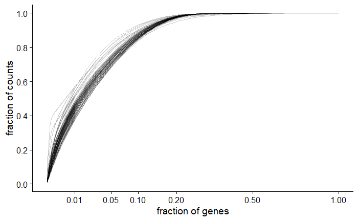

```r
plot_library_complexity(dds)
```

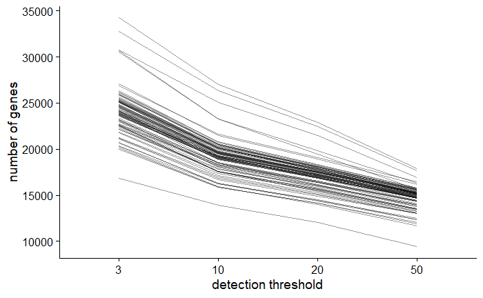

```r
plot_gene_detection(dds)
```

Perform gene filtering.

We determined `min_count` empirically by looking at the red trend line in the variance stabilization plot. Ideally, this trend line should be flat (i.e., stable).

- Not setting any `min_count` resulted in a steep, upward-sloping trend line.
- Setting it to 5 also resulted in a steep, upward-sloping trend line.

```r
dds <- filter_genes(dds, min_count = 10)
```

Transform the read counts.

From https://chipster.csc.fi/manual/deseq2-transform.html:  
You can use the resulting transformed values only for visualization and clustering, not for differential expression analysis which needs raw counts.

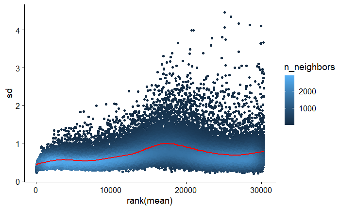

```r
vsd <- vst(dds)
mean_sd_plot(vsd)
```

Check the clustering of the samples.

If you encounter the error `Error in loadNamespace(x) : there is no package called 'ComplexHeatmap'`, uncomment and run the following code block:

```r
# install.packages("devtools", dependencies = TRUE)
# devtools::install_github("jokergoo/ComplexHeatmap")
```

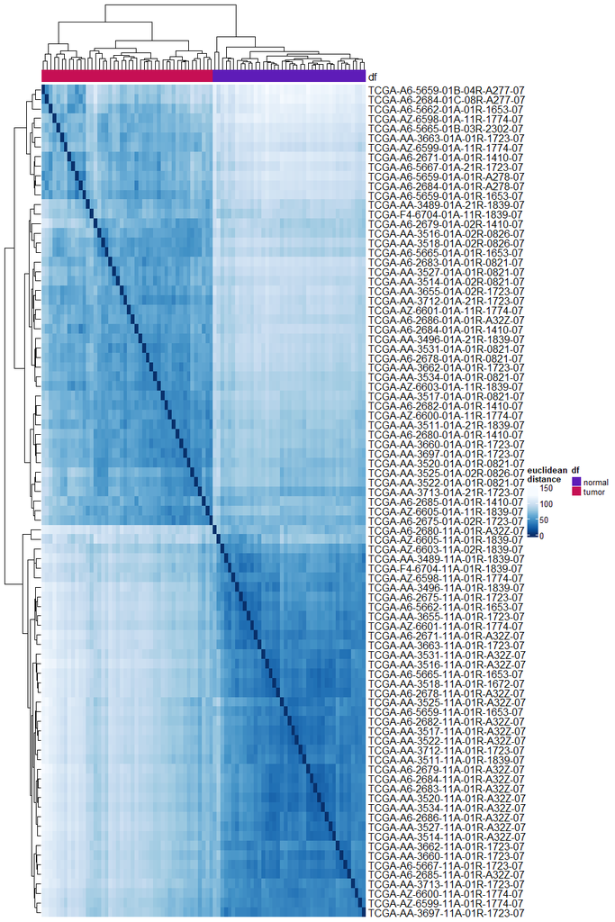

```r
set.seed(42)
plot_sample_clustering(vsd, anno_vars = c("type"), distance = "euclidean")
```

Perform principal component analysis (PCA).

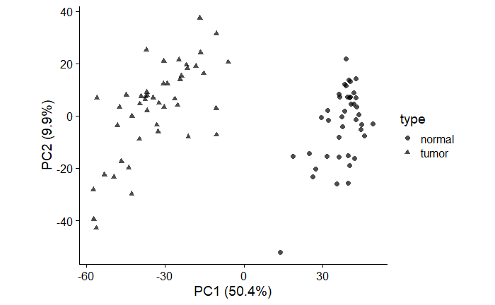

```r
plot_pca(vsd, PC_x = 1, PC_y = 2, shape_by = "type")
```

### Regulated Cell Death

Refer to `1. Exploratory Data Analysis - MSigDB Gene Sets + GTEx TPM.Rmd` for more detailed documentation on obtaining the gene sets.

#### Necroptosis

Fetch the necroptosis gene set.

```r
necroptosis.genes <- msigdbr(species = "human", category = "C5", subcategory = "GO:BP") %>%
  dplyr::filter(gs_name == "GOBP_NECROPTOTIC_SIGNALING_PATHWAY")
necroptosis.genes
```

| gs_cat | gs_subcat | gs_name | gene_symbol | entrez_gene | ensembl_gene | human_gene_symbol | human_entrez_gene | human_ensembl_gene | gs_id | gs_pmid | gs_geoid | gs_exact_source | gs_url | gs_description |
| --- | --- | --- | --- | --- | --- | --- | --- | --- | --- | --- | --- | --- | --- | --- |
| C5 | GO:BP | GOBP_NECROPTOTIC_SIGNALING_PATHWAY | FADD | 8772 | ENSG00000168040 | FADD | 8772 | ENSG00000168040 | M24779 |  |  | GO:0097527 | http://amigo.geneontology.org/amigo/term/GO:0097527 | A series of molecular signals which triggers the necroptotic death of a cell. The pathway starts with reception of a signal, is characterized by activation of receptor-interacting serine/threonine-pro… |
| C5 | GO:BP | GOBP_NECROPTOTIC_SIGNALING_PATHWAY | FAS | 355 | ENSG00000026103 | FAS | 355 | ENSG00000026103 | M24779 |  |  | GO:0097527 | http://amigo.geneontology.org/amigo/term/GO:0097527 | A series of molecular signals which triggers the necroptotic death of a cell. The pathway starts with reception of a signal, is characterized by activation of receptor-interacting serine/threonine-pro… |
| C5 | GO:BP | GOBP_NECROPTOTIC_SIGNALING_PATHWAY | FASLG | 356 | ENSG00000117560 | FASLG | 356 | ENSG00000117560 | M24779 |  |  | GO:0097527 | http://amigo.geneontology.org/amigo/term/GO:0097527 | A series of molecular signals which triggers the necroptotic death of a cell. The pathway starts with reception of a signal, is characterized by activation of receptor-interacting serine/threonine-pro… |
| C5 | GO:BP | GOBP_NECROPTOTIC_SIGNALING_PATHWAY | MLKL | 197259 | ENSG00000168404 | MLKL | 197259 | ENSG00000168404 | M24779 |  |  | GO:0097527 | http://amigo.geneontology.org/amigo/term/GO:0097527 | A series of molecular signals which triggers the necroptotic death of a cell. The pathway starts with reception of a signal, is characterized by activation of receptor-interacting serine/threonine-pro… |
| C5 | GO:BP | GOBP_NECROPTOTIC_SIGNALING_PATHWAY | RIPK1 | 8737 | ENSG00000137275 | RIPK1 | 8737 | ENSG00000137275 | M24779 |  |  | GO:0097527 | http://amigo.geneontology.org/amigo/term/GO:0097527 | A series of molecular signals which triggers the necroptotic death of a cell. The pathway starts with reception of a signal, is characterized by activation of receptor-interacting serine/threonine-pro… |
| C5 | GO:BP | GOBP_NECROPTOTIC_SIGNALING_PATHWAY | RIPK3 | 11035 | ENSG00000129465 | RIPK3 | 11035 | ENSG00000129465 | M24779 |  |  | GO:0097527 | http://amigo.geneontology.org/amigo/term/GO:0097527 | A series of molecular signals which triggers the necroptotic death of a cell. The pathway starts with reception of a signal, is characterized by activation of receptor-interacting serine/threonine-pro… |
| C5 | GO:BP | GOBP_NECROPTOTIC_SIGNALING_PATHWAY | RIPK3 | 11035 | ENSG00000285379 | RIPK3 | 11035 | ENSG00000285379 | M24779 |  |  | GO:0097527 | http://amigo.geneontology.org/amigo/term/GO:0097527 | A series of molecular signals which triggers the necroptotic death of a cell. The pathway starts with reception of a signal, is characterized by activation of receptor-interacting serine/threonine-pro… |
| C5 | GO:BP | GOBP_NECROPTOTIC_SIGNALING_PATHWAY | TLR3 | 7098 | ENSG00000164342 | TLR3 | 7098 | ENSG00000164342 | M24779 |  |  | GO:0097527 | http://amigo.geneontology.org/amigo/term/GO:0097527 | A series of molecular signals which triggers the necroptotic death of a cell. The pathway starts with reception of a signal, is characterized by activation of receptor-interacting serine/threonine-pro… |
| C5 | GO:BP | GOBP_NECROPTOTIC_SIGNALING_PATHWAY | TNF | 7124 | ENSG00000204490 | TNF | 7124 | ENSG00000204490 | M24779 |  |  | GO:0097527 | http://amigo.geneontology.org/amigo/term/GO:0097527 | A series of molecular signals which triggers the necroptotic death of a cell. The pathway starts with reception of a signal, is characterized by activation of receptor-interacting serine/threonine-pro… |
| C5 | GO:BP | GOBP_NECROPTOTIC_SIGNALING_PATHWAY | TNF | 7124 | ENSG00000206439 | TNF | 7124 | ENSG00000206439 | M24779 |  |  | GO:0097527 | http://amigo.geneontology.org/amigo/term/GO:0097527 | A series of molecular signals which triggers the necroptotic death of a cell. The pathway starts with reception of a signal, is characterized by activation of receptor-interacting serine/threonine-pro… |

[output cut: 6 more lines]

Filter the genes to include only those in the necroptosis gene set.

```r
rownames(necroptosis.genes) <- necroptosis.genes$ensembl_gene
```

```r
coad_necroptosis <- count_matrix[rownames(count_matrix) %in% necroptosis.genes$ensembl_gene, ]
coad_necroptosis <- coad_necroptosis[, rownames(samples)]

# Check if all samples in the counts dataframe are in the samples dataframe
all(colnames(coad_necroptosis) == rownames(samples))
```

Perform differential gene expression analysis.

```r
dds <- DESeqDataSetFromMatrix(
  countData = coad_necroptosis,
  colData = samples,
  design = ~type
)
dds <- filter_genes(dds, min_count = 10)
dds$type <- relevel(dds$type, ref = "normal")
dds <- DESeq(dds)
res <- results(dds)
summary(res)
```

```
out of 8 with nonzero total read count
adjusted p-value < 0.1
LFC > 0 (up)       : 2, 25%
LFC < 0 (down)     : 2, 25%
outliers [1]       : 0, 0%
low counts [2]     : 0, 0%
(mean count < 38)
[1] see 'cooksCutoff' argument of ?results
[2] see 'independentFiltering' argument of ?results
```

Prettify the display of results.

```r
deseq.results <- res
deseq.bbl.data <- data.frame(
  row.names = rownames(deseq.results),
  baseMean = deseq.results$baseMean,
  log2FoldChange = deseq.results$log2FoldChange,
  lfcSE = deseq.results$lfcSE,
  stat = deseq.results$stat,
  pvalue = deseq.results$pvalue,
  padj = deseq.results$padj,
  cancer_type = "Colon",
  gene_symbol = necroptosis.genes[rownames(deseq.results), "gene_symbol"]
)
deseq.bbl.data
```

|  | baseMean | log2FoldChange | lfcSE | stat | pvalue | padj | cancer_type | gene_symbol |
| --- | --- | --- | --- | --- | --- | --- | --- | --- |
| ENSG00000026103 | 812.79586 | -0.73365309 | 0.14226324 | -5.1570108 | 2.509233e-07 | 5.018467e-07 | Colon | FAS |
| ENSG00000117560 | 38.30547 | -0.44096237 | 0.23973882 | -1.8393449 | 6.586447e-02 | 1.053832e-01 | Colon | FASLG |
| ENSG00000129465 | 781.31915 | -0.17273184 | 0.11077023 | -1.5593706 | 1.189087e-01 | 1.585449e-01 | Colon | RIPK3 |
| ENSG00000137275 | 2029.09878 | -0.06117223 | 0.07569339 | -0.8081581 | 4.189996e-01 | 4.189996e-01 | Colon | RIPK1 |
| ENSG00000164342 | 803.91169 | -1.40923474 | 0.15158016 | -9.2969602 | 1.445183e-20 | 5.780733e-20 | Colon | TLR3 |
| ENSG00000168040 | 225.80844 | 1.26053718 | 0.17589965 | 7.1662289 | 7.709183e-13 | 2.055782e-12 | Colon | FADD |
| ENSG00000168404 | 974.98945 | 1.25144080 | 0.11550908 | 10.8341333 | 2.372010e-27 | 1.897608e-26 | Colon | MLKL |
| ENSG00000232810 | 49.37205 | 0.30058837 | 0.21221403 | 1.4164397 | 1.566468e-01 | 1.790249e-01 | Colon | TNF |

Plot the results.

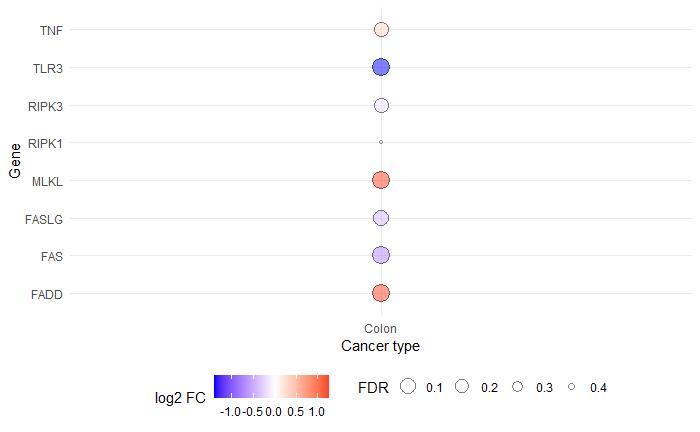

```r
ggplot(deseq.bbl.data, aes(x = cancer_type, y = gene_symbol, size = padj, fill = log2FoldChange)) +
  geom_point(alpha = 0.5, shape = 21, color = "black") +
  scale_size(trans = "reverse") +
  scale_fill_gradient2(low = "blue", mid = "white", high = "red", limits = c(min(deseq.bbl.data$log2FoldChange), max(deseq.bbl.data$log2FoldChange))) +
  theme_minimal() +
  theme(legend.position = "bottom") +
  theme(legend.position = "bottom") +
  labs(size = "FDR", fill = "log2 FC", x = "Cancer type", y = "Gene")
```

#### Ferroptosis

Fetch the ferroptosis gene set.

```r
ferroptosis.genes <- msigdbr(species = "human", category = "C2", subcategory = "CP:WIKIPATHWAYS") %>%
  dplyr::filter(gs_name == "WP_FERROPTOSIS")
ferroptosis.genes
```

| gs_cat | gs_subcat | gs_name | gene_symbol | entrez_gene | ensembl_gene | human_gene_symbol | human_entrez_gene | human_ensembl_gene | gs_id | gs_pmid | gs_geoid | gs_exact_source | gs_url | gs_description |
| --- | --- | --- | --- | --- | --- | --- | --- | --- | --- | --- | --- | --- | --- | --- |
| C2 | CP:WIKIPATHWAYS | WP_FERROPTOSIS | ACSL1 | 2180 | ENSG00000151726 | ACSL1 | 2180 | ENSG00000151726 | M39768 |  |  | WP4313 | http://www.wikipathways.org/instance/WP4313_r120500 | Ferroptosis |
| C2 | CP:WIKIPATHWAYS | WP_FERROPTOSIS | ACSL3 | 2181 | ENSG00000123983 | ACSL3 | 2181 | ENSG00000123983 | M39768 |  |  | WP4313 | http://www.wikipathways.org/instance/WP4313_r120500 | Ferroptosis |
| C2 | CP:WIKIPATHWAYS | WP_FERROPTOSIS | ACSL4 | 2182 | ENSG00000068366 | ACSL4 | 2182 | ENSG00000068366 | M39768 |  |  | WP4313 | http://www.wikipathways.org/instance/WP4313_r120500 | Ferroptosis |
| C2 | CP:WIKIPATHWAYS | WP_FERROPTOSIS | ACSL5 | 51703 | ENSG00000197142 | ACSL5 | 51703 | ENSG00000197142 | M39768 |  |  | WP4313 | http://www.wikipathways.org/instance/WP4313_r120500 | Ferroptosis |
| C2 | CP:WIKIPATHWAYS | WP_FERROPTOSIS | ACSL6 | 23305 | ENSG00000164398 | ACSL6 | 23305 | ENSG00000164398 | M39768 |  |  | WP4313 | http://www.wikipathways.org/instance/WP4313_r120500 | Ferroptosis |
| C2 | CP:WIKIPATHWAYS | WP_FERROPTOSIS | AIFM2 | 84883 | ENSG00000042286 | AIFM2 | 84883 | ENSG00000042286 | M39768 |  |  | WP4313 | http://www.wikipathways.org/instance/WP4313_r120500 | Ferroptosis |
| C2 | CP:WIKIPATHWAYS | WP_FERROPTOSIS | AKR1C1 | 1645 | ENSG00000187134 | AKR1C1 | 1645 | ENSG00000187134 | M39768 |  |  | WP4313 | http://www.wikipathways.org/instance/WP4313_r120500 | Ferroptosis |
| C2 | CP:WIKIPATHWAYS | WP_FERROPTOSIS | AKR1C2 | 1646 | ENSG00000151632 | AKR1C2 | 1646 | ENSG00000151632 | M39768 |  |  | WP4313 | http://www.wikipathways.org/instance/WP4313_r120500 | Ferroptosis |
| C2 | CP:WIKIPATHWAYS | WP_FERROPTOSIS | AKR1C3 | 8644 | ENSG00000196139 | AKR1C3 | 8644 | ENSG00000196139 | M39768 |  |  | WP4313 | http://www.wikipathways.org/instance/WP4313_r120500 | Ferroptosis |
| C2 | CP:WIKIPATHWAYS | WP_FERROPTOSIS | ALOX15 | 246 | ENSG00000161905 | ALOX15 | 246 | ENSG00000161905 | M39768 |  |  | WP4313 | http://www.wikipathways.org/instance/WP4313_r120500 | Ferroptosis |

[output cut: 56 more lines]

Filter the genes to include only those in the ferroptosis gene set.

```r
rownames(ferroptosis.genes) <- ferroptosis.genes$ensembl_gene
```

```r
coad_ferroptosis <- count_matrix[rownames(count_matrix) %in% ferroptosis.genes$ensembl_gene, ]
coad_ferroptosis <- coad_ferroptosis[, rownames(samples)]

# Check if all samples in the counts dataframe are in the samples dataframe
all(colnames(coad_ferroptosis) == rownames(samples))
```

Perform differential gene expression analysis.

```r
dds <- DESeqDataSetFromMatrix(
  countData = coad_ferroptosis,
  colData = samples,
  design = ~type
)
dds <- filter_genes(dds, min_count = 10)
dds$type <- relevel(dds$type, ref = "normal")
dds <- DESeq(dds)
```

```
-- replacing outliers and refitting for 2 genes
-- DESeq argument 'minReplicatesForReplace' = 7
-- original counts are preserved in counts(dds)
```

```r
res <- results(dds)
summary(res)
```

```
out of 63 with nonzero total read count
adjusted p-value < 0.1
LFC > 0 (up)       : 24, 38%
LFC < 0 (down)     : 19, 30%
outliers [1]       : 0, 0%
low counts [2]     : 0, 0%
(mean count < 8)
[1] see 'cooksCutoff' argument of ?results
[2] see 'independentFiltering' argument of ?results
```

Prettify the display of results.

```r
deseq.results <- res
deseq.bbl.data <- data.frame(
  row.names = rownames(deseq.results),
  baseMean = deseq.results$baseMean,
  log2FoldChange = deseq.results$log2FoldChange,
  lfcSE = deseq.results$lfcSE,
  stat = deseq.results$stat,
  pvalue = deseq.results$pvalue,
  padj = deseq.results$padj,
  cancer_type = "Colon",
  gene_symbol = ferroptosis.genes[rownames(deseq.results), "gene_symbol"]
)
deseq.bbl.data
```

|  | baseMean | log2FoldChange | lfcSE | stat | pvalue | padj | cancer_type | gene_symbol |
| --- | --- | --- | --- | --- | --- | --- | --- | --- |
| ENSG00000001084 | 1609.796938 | 0.27213638 | 0.09212937 | 2.9538504 | 3.138361e-03 | 5.991417e-03 | Colon | GCLC |
| ENSG00000007952 | 5983.418730 | 0.91964628 | 0.21911692 | 4.1970574 | 2.704054e-05 | 7.098141e-05 | Colon | NOX1 |
| ENSG00000023909 | 862.075603 | 0.27095805 | 0.13741073 | 1.9718843 | 4.862282e-02 | 7.293423e-02 | Colon | GCLM |
| ENSG00000042286 | 1687.876818 | 0.09091204 | 0.13241555 | 0.6865662 | 4.923562e-01 | 5.539007e-01 | Colon | AIFM2 |
| ENSG00000047457 | 285.842538 | -2.65419858 | 0.25135775 | -10.5594460 | 4.593651e-26 | 5.788000e-25 | Colon | CP |
| ENSG00000057663 | 2016.155121 | -0.18976202 | 0.07644660 | -2.4822820 | 1.305439e-02 | 2.164281e-02 | Colon | ATG5 |
| ENSG00000068366 | 1927.113505 | 1.07139023 | 0.15248226 | 7.0263269 | 2.120414e-12 | 9.541863e-12 | Colon | ACSL4 |
| ENSG00000072274 | 14407.740951 | 0.72101146 | 0.14308965 | 5.0388792 | 4.682659e-07 | 1.638931e-06 | Colon | TFRC |
| ENSG00000078668 | 4461.690405 | 0.13351365 | 0.09264708 | 1.4410994 | 1.495566e-01 | 1.922871e-01 | Colon | VDAC3 |
| ENSG00000079459 | 8507.872357 | 0.44946639 | 0.11347789 | 3.9608280 | 7.469032e-05 | 1.882196e-04 | Colon | FDFT1 |

[output cut: 53 more lines]

Plot the results.

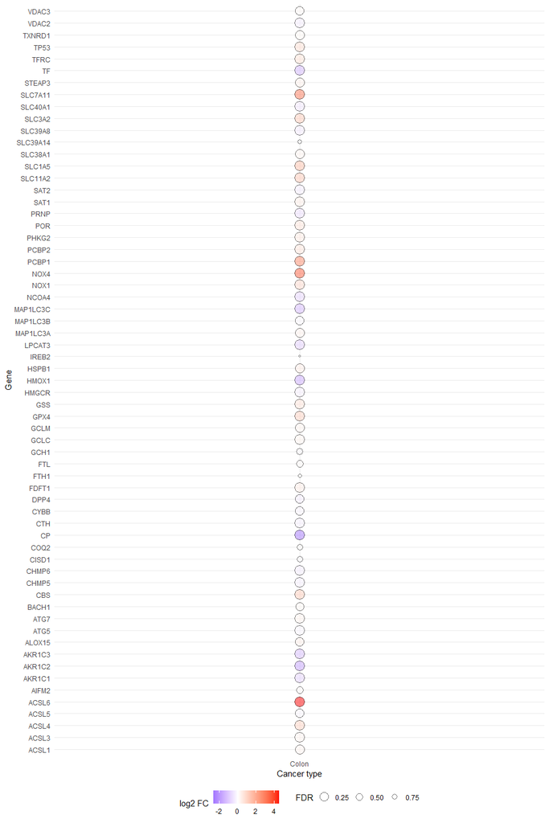

```r
ggplot(deseq.bbl.data, aes(x = cancer_type, y = gene_symbol, size = padj, fill = log2FoldChange)) +
  geom_point(alpha = 0.5, shape = 21, color = "black") +
  scale_size(trans = "reverse") +
  scale_fill_gradient2(low = "blue", mid = "white", high = "red", limits = c(min(deseq.bbl.data$log2FoldChange), max(deseq.bbl.data$log2FoldChange))) +
  theme_minimal() +
  theme(legend.position = "bottom") +
  theme(legend.position = "bottom") +
  labs(size = "FDR", fill = "log2 FC", x = "Cancer type", y = "Gene")
```

#### Pyroptosis

Fetch the pyroptosis gene set.

```r
pyroptosis.genes <- msigdbr(species = "human", category = "C2", subcategory = "CP:REACTOME") %>%
  dplyr::filter(gs_name == "REACTOME_PYROPTOSIS")
pyroptosis.genes
```

| gs_cat | gs_subcat | gs_name | gene_symbol | entrez_gene | ensembl_gene | human_gene_symbol | human_entrez_gene | human_ensembl_gene | gs_id | gs_pmid | gs_geoid | gs_exact_source | gs_url | gs_description |
| --- | --- | --- | --- | --- | --- | --- | --- | --- | --- | --- | --- | --- | --- | --- |
| C2 | CP:REACTOME | REACTOME_PYROPTOSIS | BAK1 | 578 | ENSG00000030110 | BAK1 | 578 | ENSG00000030110 | M41805 |  |  | R-HSA-5620971 | https://www.reactome.org/content/detail/R-HSA-5620971\|https://reactome.org/PathwayBrowser/#/R-HSA-5620971 | Pyroptosis |
| C2 | CP:REACTOME | REACTOME_PYROPTOSIS | BAX | 581 | ENSG00000087088 | BAX | 581 | ENSG00000087088 | M41805 |  |  | R-HSA-5620971 | https://www.reactome.org/content/detail/R-HSA-5620971\|https://reactome.org/PathwayBrowser/#/R-HSA-5620971 | Pyroptosis |
| C2 | CP:REACTOME | REACTOME_PYROPTOSIS | CASP1 | 834 | ENSG00000137752 | CASP1 | 834 | ENSG00000137752 | M41805 |  |  | R-HSA-5620971 | https://www.reactome.org/content/detail/R-HSA-5620971\|https://reactome.org/PathwayBrowser/#/R-HSA-5620971 | Pyroptosis |
| C2 | CP:REACTOME | REACTOME_PYROPTOSIS | CASP3 | 836 | ENSG00000164305 | CASP3 | 836 | ENSG00000164305 | M41805 |  |  | R-HSA-5620971 | https://www.reactome.org/content/detail/R-HSA-5620971\|https://reactome.org/PathwayBrowser/#/R-HSA-5620971 | Pyroptosis |
| C2 | CP:REACTOME | REACTOME_PYROPTOSIS | CASP4 | 837 | ENSG00000196954 | CASP4 | 837 | ENSG00000196954 | M41805 |  |  | R-HSA-5620971 | https://www.reactome.org/content/detail/R-HSA-5620971\|https://reactome.org/PathwayBrowser/#/R-HSA-5620971 | Pyroptosis |
| C2 | CP:REACTOME | REACTOME_PYROPTOSIS | CASP5 | 838 | ENSG00000137757 | CASP5 | 838 | ENSG00000137757 | M41805 |  |  | R-HSA-5620971 | https://www.reactome.org/content/detail/R-HSA-5620971\|https://reactome.org/PathwayBrowser/#/R-HSA-5620971 | Pyroptosis |
| C2 | CP:REACTOME | REACTOME_PYROPTOSIS | CHMP2A | 27243 | ENSG00000130724 | CHMP2A | 27243 | ENSG00000130724 | M41805 |  |  | R-HSA-5620971 | https://www.reactome.org/content/detail/R-HSA-5620971\|https://reactome.org/PathwayBrowser/#/R-HSA-5620971 | Pyroptosis |
| C2 | CP:REACTOME | REACTOME_PYROPTOSIS | CHMP2B | 25978 | ENSG00000083937 | CHMP2B | 25978 | ENSG00000083937 | M41805 |  |  | R-HSA-5620971 | https://www.reactome.org/content/detail/R-HSA-5620971\|https://reactome.org/PathwayBrowser/#/R-HSA-5620971 | Pyroptosis |
| C2 | CP:REACTOME | REACTOME_PYROPTOSIS | CHMP3 | 51652 | ENSG00000115561 | CHMP3 | 51652 | ENSG00000115561 | M41805 |  |  | R-HSA-5620971 | https://www.reactome.org/content/detail/R-HSA-5620971\|https://reactome.org/PathwayBrowser/#/R-HSA-5620971 | Pyroptosis |
| C2 | CP:REACTOME | REACTOME_PYROPTOSIS | CHMP4A | 29082 | ENSG00000254505 | CHMP4A | 29082 | ENSG00000254505 | M41805 |  |  | R-HSA-5620971 | https://www.reactome.org/content/detail/R-HSA-5620971\|https://reactome.org/PathwayBrowser/#/R-HSA-5620971 | Pyroptosis |

[output cut: 20 more lines]

Filter the genes to include only those in the pyroptosis gene set.

```r
rownames(pyroptosis.genes) <- pyroptosis.genes$ensembl_gene
```

```r
coad_pyroptosis <- count_matrix[rownames(count_matrix) %in% pyroptosis.genes$ensembl_gene, ]
coad_pyroptosis <- coad_pyroptosis[, rownames(samples)]

# Check if all samples in the counts dataframe are in the samples dataframe
all(colnames(coad_pyroptosis) == rownames(samples))
```

Perform differential gene expression analysis.

```r
dds <- DESeqDataSetFromMatrix(
  countData = coad_pyroptosis,
  colData = samples,
  design = ~type
)
dds <- filter_genes(dds, min_count = 10)
dds$type <- relevel(dds$type, ref = "normal")
dds <- DESeq(dds)
```

```
-- replacing outliers and refitting for 1 genes
-- DESeq argument 'minReplicatesForReplace' = 7
-- original counts are preserved in counts(dds)
```

```r
res <- results(dds)
summary(res)
```

```
out of 27 with nonzero total read count
adjusted p-value < 0.1
LFC > 0 (up)       : 10, 37%
LFC < 0 (down)     : 7, 26%
outliers [1]       : 0, 0%
low counts [2]     : 0, 0%
(mean count < 16)
[1] see 'cooksCutoff' argument of ?results
[2] see 'independentFiltering' argument of ?results
```

Prettify the display of results.

```r
deseq.results <- res
deseq.bbl.data <- data.frame(
  row.names = rownames(deseq.results),
  baseMean = deseq.results$baseMean,
  log2FoldChange = deseq.results$log2FoldChange,
  lfcSE = deseq.results$lfcSE,
  stat = deseq.results$stat,
  pvalue = deseq.results$pvalue,
  padj = deseq.results$padj,
  cancer_type = "Colon",
  gene_symbol = pyroptosis.genes[rownames(deseq.results), "gene_symbol"]
)
deseq.bbl.data
```

|  | baseMean | log2FoldChange | lfcSE | stat | pvalue | padj | cancer_type | gene_symbol |
| --- | --- | --- | --- | --- | --- | --- | --- | --- |
| ENSG00000030110 | 2013.25240 | -0.43898301 | 0.10896636 | -4.02861040 | 5.610751e-05 | 1.262419e-04 | Colon | BAK1 |
| ENSG00000073282 | 17.20881 | -0.28792091 | 0.27446722 | -1.04901747 | 2.941701e-01 | 3.782187e-01 | Colon | TP63 |
| ENSG00000083937 | 3350.36637 | -0.23578112 | 0.11826377 | -1.99368854 | 4.618610e-02 | 7.335440e-02 | Colon | CHMP2B |
| ENSG00000087088 | 3000.78182 | 0.71053151 | 0.14189535 | 5.00743351 | 5.516060e-07 | 1.489336e-06 | Colon | BAX |
| ENSG00000100453 | 367.99014 | 2.57443809 | 0.26750266 | 9.62397185 | 6.333714e-22 | 5.700343e-21 | Colon | GZMB |
| ENSG00000101421 | 12139.29731 | 0.20091672 | 0.13183220 | 1.52403373 | 1.275003e-01 | 1.855957e-01 | Colon | CHMP4B |
| ENSG00000104518 | 3931.12267 | 0.25220618 | 0.16980753 | 1.48524730 | 1.374783e-01 | 1.855957e-01 | Colon | GSDMD |
| ENSG00000105928 | 179.98184 | 0.86953040 | 0.26030280 | 3.34045736 | 8.364052e-04 | 1.613067e-03 | Colon | GSDME |
| ENSG00000115008 | 54.20766 | 2.96291009 | 0.30282911 | 9.78409938 | 1.317631e-22 | 1.778802e-21 | Colon | IL1A |
| ENSG00000115561 | 4033.18955 | -0.03831356 | 0.11533213 | -0.33220195 | 7.397368e-01 | 7.681882e-01 | Colon | CHMP3 |

[output cut: 17 more lines]

Plot the results.

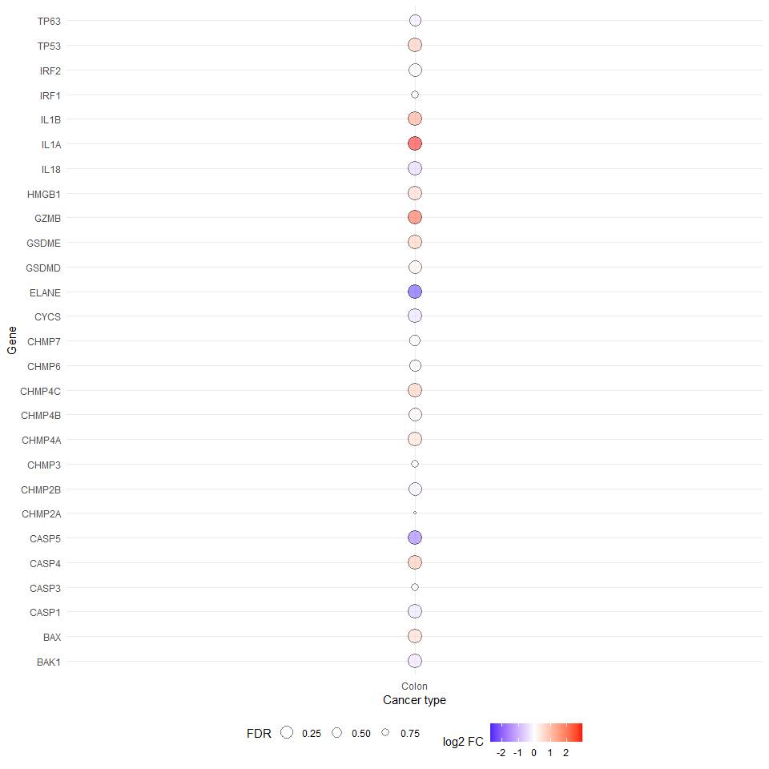

```r
ggplot(deseq.bbl.data, aes(x = cancer_type, y = gene_symbol, size = padj, fill = log2FoldChange)) +
  geom_point(alpha = 0.5, shape = 21, color = "black") +
  scale_size(trans = "reverse") +
  scale_fill_gradient2(low = "blue", mid = "white", high = "red", limits = c(min(deseq.bbl.data$log2FoldChange), max(deseq.bbl.data$log2FoldChange))) +
  theme_minimal() +
  theme(legend.position = "bottom") +
  theme(legend.position = "bottom") +
  labs(size = "FDR", fill = "log2 FC", x = "Cancer type", y = "Gene")
```

[^1]: De La Salle University, Manila, Philippines, kim_leejra@dlsu.edu.ph
[^2]: De La Salle University, Manila, Philippines, gonzales.markedward@gmail.com
[^3]: De La Salle University, Manila, Philippines, anish.shrestha@dlsu.edu.ph